# GLM for t-tests and ANOVAs

PSM 2

Bennett Kleinberg

29 Jan 2019

## Welcome

Probability, Statistics & Modeling II

### Lecture 4

The GLM for group mean comparisons

## About the module

- 7.5 ECTS (0.5 UCL credits)
- = 150 learning hours
- = 11 weeks with *14 hours per week*
- 3 contact-hours per week
- –> 11 hours self-study per week

## Expected self-study

- Revise the lecture (your responsibility)
- Replicate the code/examples
- Read the required literature (read, annotate, summarise)
- Read additional literature if necessary
- Design own code examples to understand the concept
- If still unclear: post it on Moodle or ask us

### What question do you have?

## Brief recap logistic regression

- problem of linear models for discrete/binary outcome variables
- needed: transformation of the outcome variable

## From …

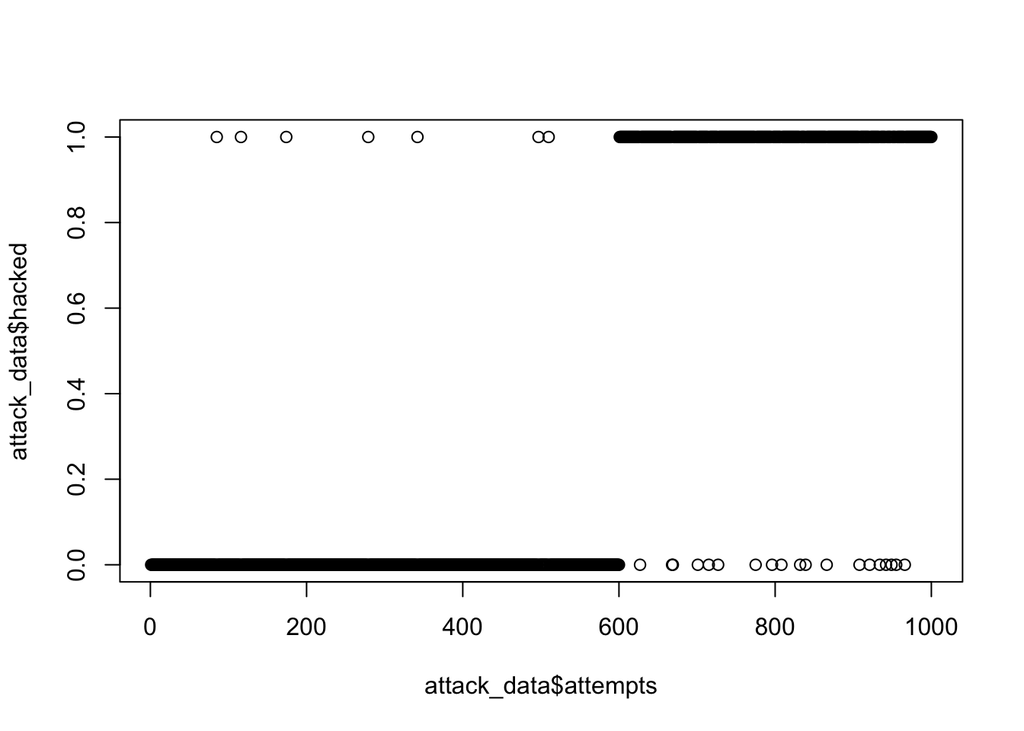

## … to:

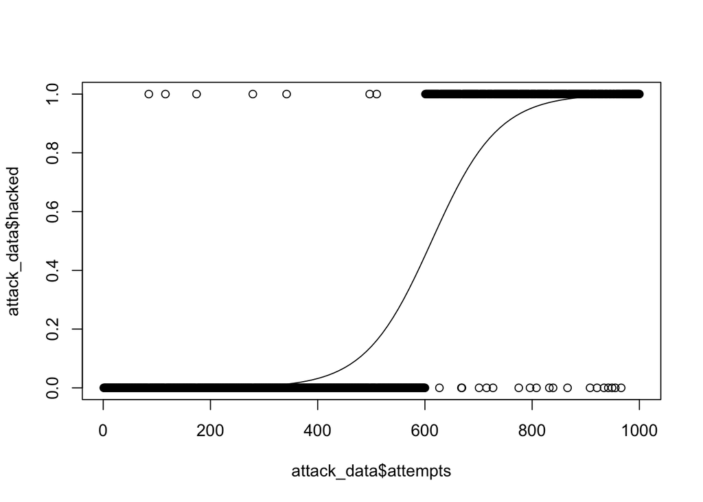

## Re-transform for the interpretation!

- remember: we model the log-odds
- so: un-log the natural logarithm
- then: use the odds, or transform to probabilities

## Your turn

- Linear model
  - `income ~ age`
  - intercept = 10,0000
  - b1 = 5,000

## Your turn

- Linear model
  - `income ~ age*gender`
  - intercept = 10,0000
  - b1 (age) = 4,000
  - b2 (gender, 0 = female, 1 = male) = 12,000
  - b3 (age*gender) = 2,000

## Your turn

- Logistic model
  - `failed ~ hours_spent`
  - intercept = -4.50
  - b1 = 0.60

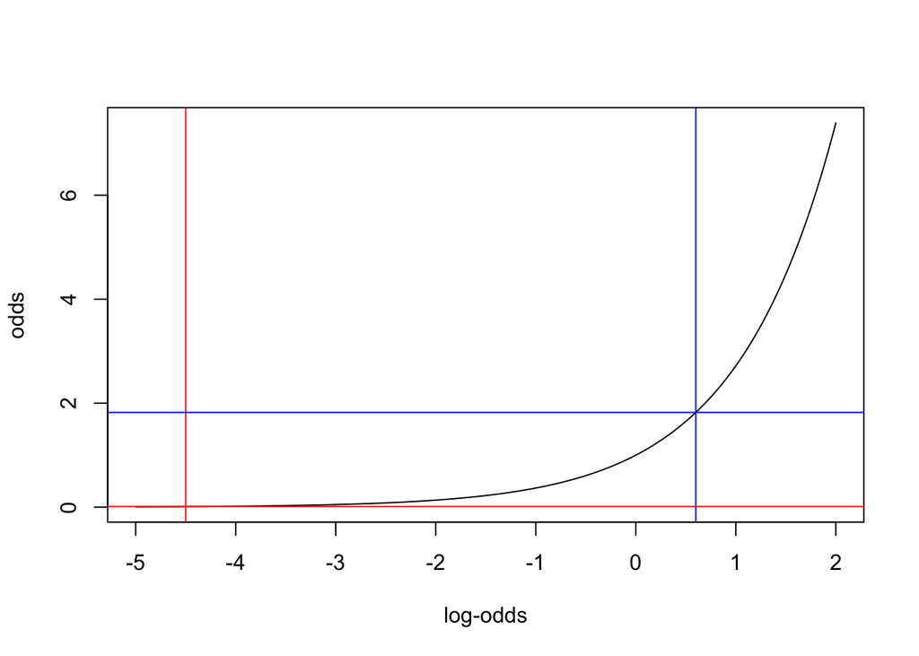

## Today

- Mean comparison
  - t-tests
  - ANOVA
  - GLM implementation

### Mean comparisons

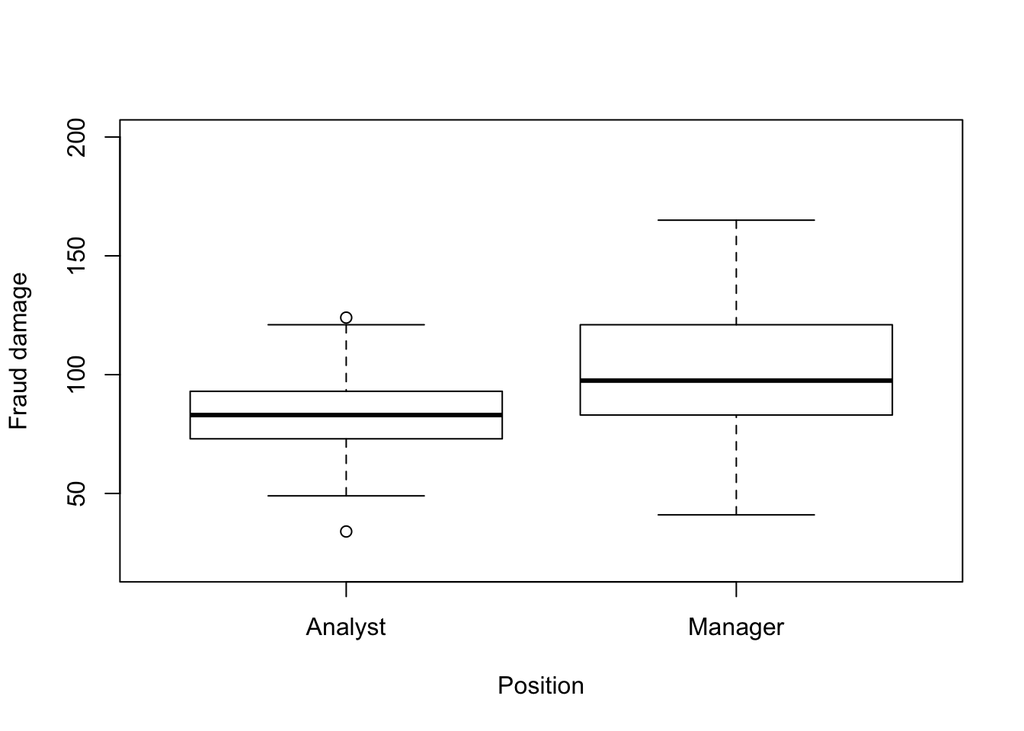

## Numerical values

Mean:

```
## Analyst Manager
##   82.92  101.02
```

SD:

```
##  Analyst  Manager
## 18.11735 27.84028
```

Is fraud by managers more damaging than fraud by analysts?

## Non-statistical answer

**Yes, because:**

```
## Analyst Manager
##   82.92  101.02
```

And: Manager > Analyst

### Why is this problematic?

## Inferential statistics

- Sample –> Population
- infere parameters of the population
- from a sample (of that population)

## All data stem from distributions

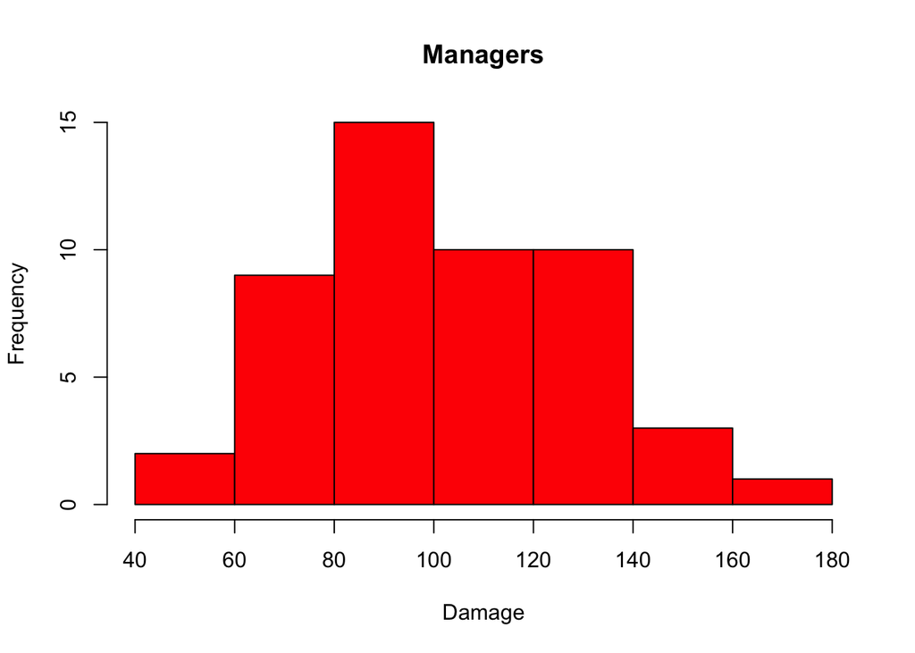

## All data stem from distributions

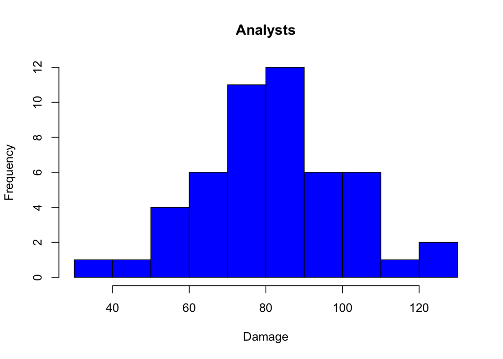

## Comparison of 2 groups

- Are the means of the groups statistically significantly different?
- Different phrasing: do the samples stem from different distributions?

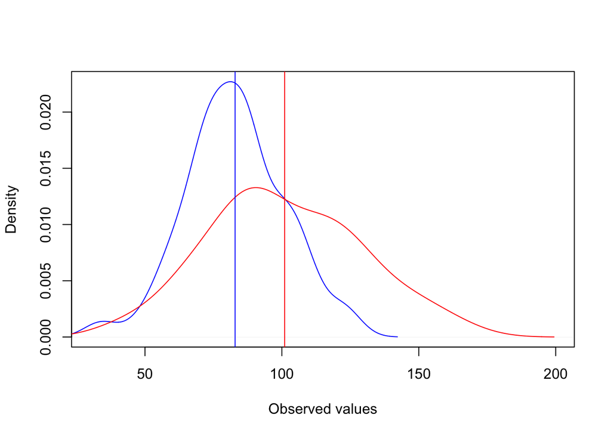

**Do** the samples stem from different distributions?

- decision criterion needed
- problem: there is always some overlap
- wanted: a threshold that we deem practically irrelevant in overlap

## Hypothesis testing

- Null hypothesis: there is no differece (i.e. Managers == Analysts)
- Alternative hypothesis: there is a difference (e.g. Managers > Analysts)

```r
mean(df$damage[df$role == 'Manager'] - df$damage[df$role == 'Analyst'])
```

```
## [1] 18.1
```

> Wanted: a value that expresses the frequentist probability of observing the mean difference of 18.10 (or more extreme) if the null hypothesis were true.

–> **called the p-value**

## Thresholds for the p-value

- aim: test whether you can reject the null hypothesis
- wanted: a threshold that we deem practically irrelevant in overlap
- threshold is called the significance level (alpha level)
- analogous to: a threshold that we deem acceptable in making a Type I error
- used to be: `p < .05`
- changes under way:
  - [redefine to `p < .005`](https://www.nature.com/articles/s41562-017-0189-z)
  - [justify your own threshold](https://www.nature.com/articles/s41562-018-0311-x)
  - rejection of p-values altogether

## Calculating the p-value

For two groups: t-test

- Assumes:
  - normality of outcome variable
  - independence of observations
  - equality of variance (corrected by default)

(non-parametric tests –> next week)

## t-test

```r
t.test(df$damage ~ df$role)
```

```
##
##  Welch Two Sample t-test
##
## data:  df$damage by df$role
## t = -3.8531, df = 84.191, p-value = 0.0002269
## alternative hypothesis: true difference in means is not equal to 0
## 95 percent confidence interval:
##  -27.441161  -8.758839
## sample estimates:
## mean in group Analyst mean in group Manager
##                 82.92                101.02
```

## t-test reporting

```r
t = -3.8531, df = 84.191, p-value = 0.0002269
```

> The damage in $ lost was higher for managers (M = 101.02, SD = 27.84) than for analysts (M = 82.92, SD = 18.12), *t*(84.19) = -3.85, *p* < .001.

Note: always three decimals for the p-value, unless p < .001.

(more in week 7)

### What if there are three groups?

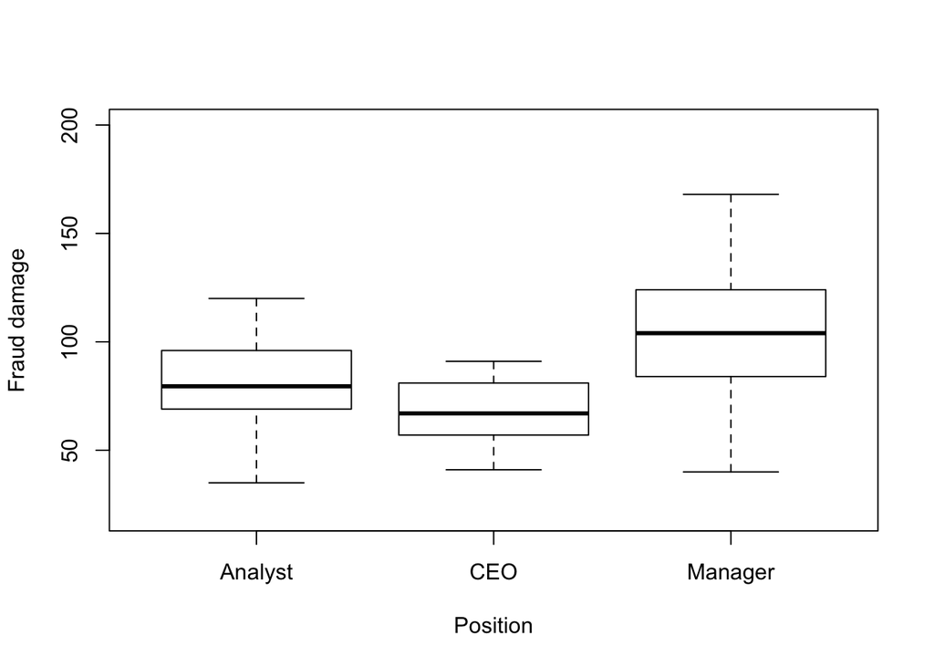

## Idea

- Test whether all three means are the same
- Could use 3 t-tests:
  - Analysts vs CEOs
  - CEOs vs Managers
  - Managers vs Analysts
- problem: [multiple t-tests increase Type 1 error](https://en.wikipedia.org/wiki/Multiple_comparisons_problem)
- Null hypothesis: Analyst = CEO = Manager
- Alt. hypothesis: the means are affected by the factor Position (3 levels)

## Variance

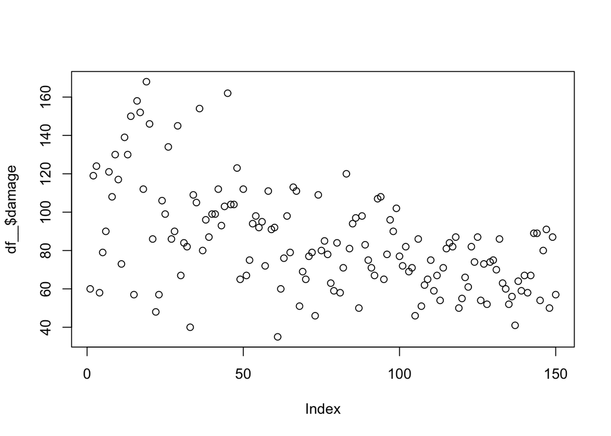

## Analysis of VARIANCE

Total variance = explained variance + unexplained variance

- **explained variance**: variation that is attributable to the factor Position
- **unexplained variance**: variation not attributable to the factor Position

## Total variance

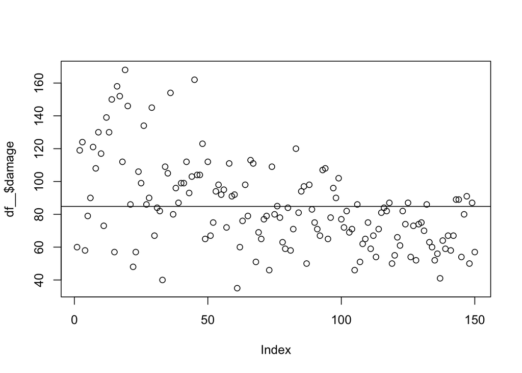

## Total variance

| damage | grandmean | squared_diff |
| --- | --- | --- |
| 60 | 84.80667 | 615.37071 |
| 119 | 84.80667 | 1169.18404 |
| 124 | 84.80667 | 1536.11738 |
| 58 | 84.80667 | 718.59738 |
| 79 | 84.80667 | 33.71738 |
| 90 | 84.80667 | 26.97071 |
| 121 | 84.80667 | 1309.95738 |
| 108 | 84.80667 | 537.93071 |
| 130 | 84.80667 | 2042.43738 |
| 117 | 84.80667 | 1036.41071 |

## Total variance

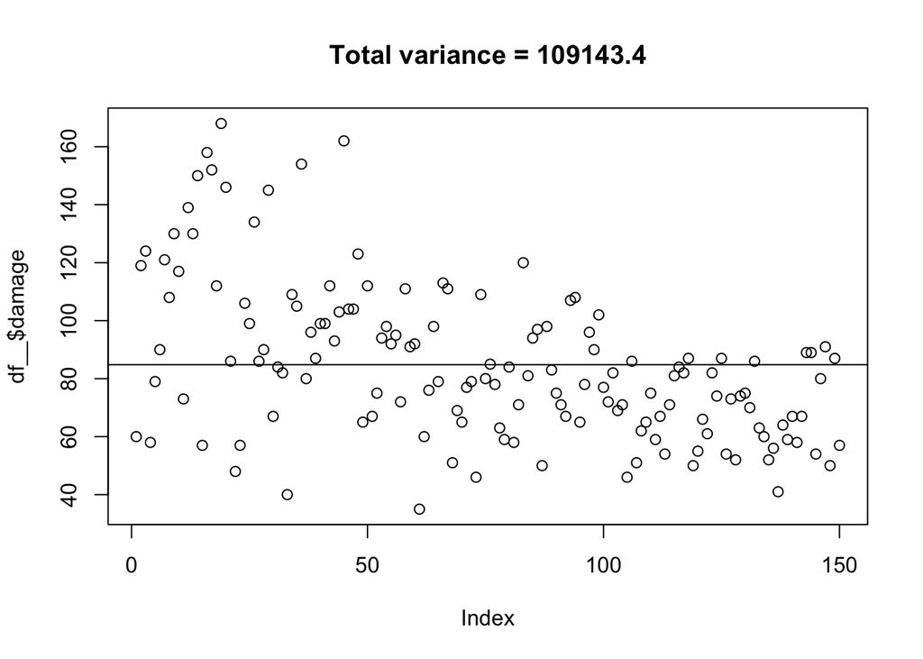

## Partitioning of variance

Total variance = explained variance + unexplained variance

109143.40 = **explained variance** + unexplained variance

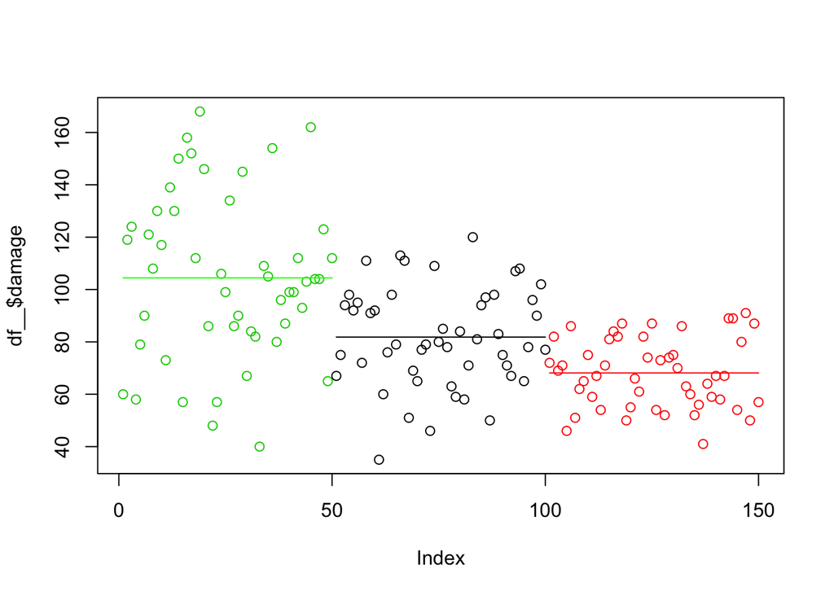

## Partitioning of variance

109143.40 = **explained variance** + unexplained variance

**explained variance**

- (variance group 1 * size of group 1)
- (variance group 2 * size of group 2)
- (variance group 3 * size of group 3)

Shortcut:

- (mean group 1 - grand mean)<sup>2</sup>
- (mean group 2 - grand mean)<sup>2</sup>
- (mean group 3 - grand mean)<sup>2</sup>
- sum these and multiply by *n* per group

## Explained variance

| group | groupmean | grandmean | squared_diff |
| --- | --- | --- | --- |
| Manager | 104.44 | 84.81 | 385.47 |
| Analyst | 81.84 | 84.81 | 8.80 |
| CEO | 68.14 | 84.81 | 277.78 |
| SUM | - | - | 672.05 |

```r
672.05 * 50
```

```
## [1] 33602.5
```

## Partitioning of variance

109143.40 = **33602.50** + unexplained variance

–>

unexplained variance = 75540.90

*We want to know: how much more variance is explained compared to non-explained.*

## Degrees of freedom

| source | variance |
| --- | --- |
| explained (factor Position) | 33602.50 |
| unexplained | 75540.90 |
| total | 109143.40 |

But: different number of values used for calculation!

## Degrees of freedom (df)

> df = number of values that are free to vary

| source | variance | df |
| --- | --- | --- |
| explained (factor Position) | 33602.50 | 2 |
| unexplained | 75540.90 | 147 |
| total | 109143.40 | 149 |

- total_df = explained_df + unexplained_df
- total_df = *n* - 1
- unexplained_df = *n* - k
- k = number of levels of the factor (here: Position)

## Corrected table of variance

| source | variance | df | mean SSq |
| --- | --- | --- | --- |
| explained (factor Position) | 33602.50 | 2 | 16801 |
| unexplained | 75540.90 | 147 | 514 |
| total | 109143.40 | 149 | - |

How much more variance is explained compared to non-explained?

## The F-test

F-statistic = mean SSq explained / mean SSq unexplained

```r
16801 / 514
```

```
## [1] 32.68677
```

> The explained variance (due to the factor Position) is 32.69 times higher than the unexplained variance.

*Is this significant?*

## ANOVA in R

```r
summary(aov(df__$damage ~ df__$role))
```

```
##              Df Sum Sq Mean Sq F value   Pr(>F)
## df__$role     2  33602   16801   32.69 1.79e-12 ***
## Residuals   147  75541     514
## ---
## Signif. codes:  0 '***' 0.001 '**' 0.01 '*' 0.05 '.' 0.1 ' ' 1
```

> The one-way ANOVA revealed that there was a significant main effect of *Position* (CEO, Manager, Analyst) on the damage in USD, *F*(2, 147) = 32.69, *p* < .001.

## ANOVA as omnibus test

Now we know whether there is an overall effect …

*Important:* only now do you have statistical justification proceed with *follow-up contrasts*.

If ANOVA *ns* –> analysis stops here!!!!!!!

## ANOVA interpretation

Step 1: The one-way ANOVA revealed that there was a significant main effect of *Position* (CEO, Manager, Analyst) on the damage in USD, *F*(2, 147) = 32.69, *p* < .001.

Step 2: follow-up contrasts

- t-test: CEO vs Manager
- t-test: CEO vs Analysts
- t-test: Manager vs Analysts

## Follow-up contrasts

```r
t.test(df__$damage[df__$role != 'Analyst'] ~ df__$role[df__$role != 'Analyst'])
t.test(df__$damage[df__$role != 'Manager'] ~ df__$role[df__$role != 'Manager'])
t.test(df__$damage[df__$role != 'CEO'] ~ df__$role[df__$role != 'CEO'])
```

| comparison | t | df | p |
| --- | --- | --- | --- |
| CEO vs Manager | -7.4734 | 65.80 | < .001 |
| CEO vs Analysts | 4.1717 | 87.70 | < .001 |
| Manager vs Analysts | -4.33 | 80.31 | < .001 |

## ANOVA interpretation

Step 1: The one-way ANOVA revealed that there was a significant main effect of *Position* (CEO, Manager, Analyst) on the damage in USD, *F*(2, 147) = 32.69, *p* < .001.

Step 2: follow-up contrasts

|  | mean |
| --- | --- |
| Analyst | 81.84 |
| CEO | 68.14 |
| Manager | 104.44 |

> Follow-up contrasts revealed that the damaga (in $) was smaller when caused by CEOs (M = 68.14, SD = 13.31) than when caused by Managers (M = 104.44, SD = 31.67), *t*(65.80) = -7.47, *p* < .001. …

## Types of ANOVAs

- One predictor (factor)
  - One-way ANOVA
  - 2+ levels
- Two predictors (factors)
  - Two-way ANOVA
  - 2+ levels by 2+ levels
  - e.g. `role*gender` –> 2 by 3 ANOVA
- Always note whether the factor is within-subjects or between-subjects
  - All factors within: within-subjects ANOVA
  - All facors between: between-subjects ANOVA
  - Both: mixed ANOVA

## ANOVA & GLM

- both resemble each other (main effects, interaction)
- more so: they are the same for categorical predictors
- predictors in ANOVA: means vs grandmean
- predictors in linear regression: dummy coded levels

## ANOVA & GLM

`lm(damage ~ role, data=df__)`

|  | beta | SE | t-statistic | p-value |
| --- | --- | --- | --- | --- |
| (Intercept) | 81.84 | 3.205884 | 25.528057 | 0.0000000 |
| roleCEO | -13.70 | 4.533805 | -3.021744 | 0.0029654 |
| roleManager | 22.60 | 4.533805 | 4.984775 | 0.0000017 |

*Beta coefficients are the group means respective to the reference group!*

## ANOVA & GLM

|  | beta |
| --- | --- |
| (Intercept) | 81.84 |
| roleCEO | -13.70 |
| roleManager | 22.60 |

```r
knitr::kable(tapply(df__$damage, df__$role, mean), col.names = c('mean'))
```

|  | mean |
| --- | --- |
| Analyst | 81.84 |
| CEO | 68.14 |
| Manager | 104.44 |

## ANOVA & GLM

Look at the output:

*Linear Model:*

```r
F-statistic: 32.69 on 2 and 147 DF,  p-value: 1.793e-12
```

*ANOVA:*

```r
             Df Sum Sq Mean Sq F value   Pr(>F)
df__$role     2  33602   16801   32.69 1.79e-12 ***
Residuals   147  75541     514
```

## ANOVA & GLM

Same omnibus logic:

- if the F-statistic in the regression is not significant
- … then you cannot conclude an overall effect of the factor

## t-test & ANOVA

- ANOVA = regression with categorical predictor(s) with 2+ levels
- t-test = one-way ANOVA with 2 two levels.
- –> t-test = regression with one categorical predictors with 2 levels

## t-test & GLM

- t-test

```r
#Managers and Analysts only
t = -3.8531, df = 84.191, p-value = 0.0002269
```

- as ANOVA

```r
summary(aov(df$damage ~ df$role))
```

```
##             Df Sum Sq Mean Sq F value   Pr(>F)
## df$role      1   8190    8190   14.85 0.000208 ***
## Residuals   98  54063     552
## ---
## Signif. codes:  0 '***' 0.001 '**' 0.01 '*' 0.05 '.' 0.1 ' ' 1
```

- ANOVA and t-test: $F = t^2$ –> $t = \sqrt F$

```r
(-3.8531)^2
```

```
## [1] 14.84638
```

```r
sqrt(14.84)
```

```
## [1] 3.852272
```

## t-test & GLM

If the ANOVA is a linear regression,  
so is the t-test:

`lm(damage ~ role, data=df)`

|  | Estimate | Std. Error | t value | Pr(>\|t\|) |
| --- | --- | --- | --- | --- |
| (Intercept) | 82.92 | 3.321626 | 24.963681 | 0.0000000 |
| roleManager | 18.10 | 4.697488 | 3.853123 | 0.0002083 |

## RECAP

- comparing 2 groups
- t-test
- t-test as GLM
- comparing multiple groups
- ANOVA as GLM

## Outlook

**Tutorial**

- logistic regression
- ANOVA

**Next week**

- Non-parametric methods
- discrete data analysis